# Global Crop Yield

### Inspired by Julia Silge

For this week's tidytuesday data on [global crop yields around the world] (https://github.com/rfordatascience/tidytuesday/blob/master/data/2020/2020-09-01/readme.md), we want to create a model that will estimate how crop yields are changing around the world. There are 5 different data, but we will not look at all of them.

## Data Exploration

We first get the data from the link above. For this analysis, we'll only use key_crop_yields and land_use data.

```r
tidy_yields <-
  key_crop_yields %>%
  janitor::clean_names() %>%
  pivot_longer(wheat_tonnes_per_hectare:bananas_tonnes_per_hectare,
    names_to = "crop", values_to = "yield") %>%
  mutate(crop = str_remove(crop, "_tonnes_per_hectare")) %>%
  filter(crop %in% c("wheat", "rice", "maize", "barley"),
    entity %in% top_countries,
    !is.na(yield))
```

We can visualize our data now to observe the change of crop yield over time.

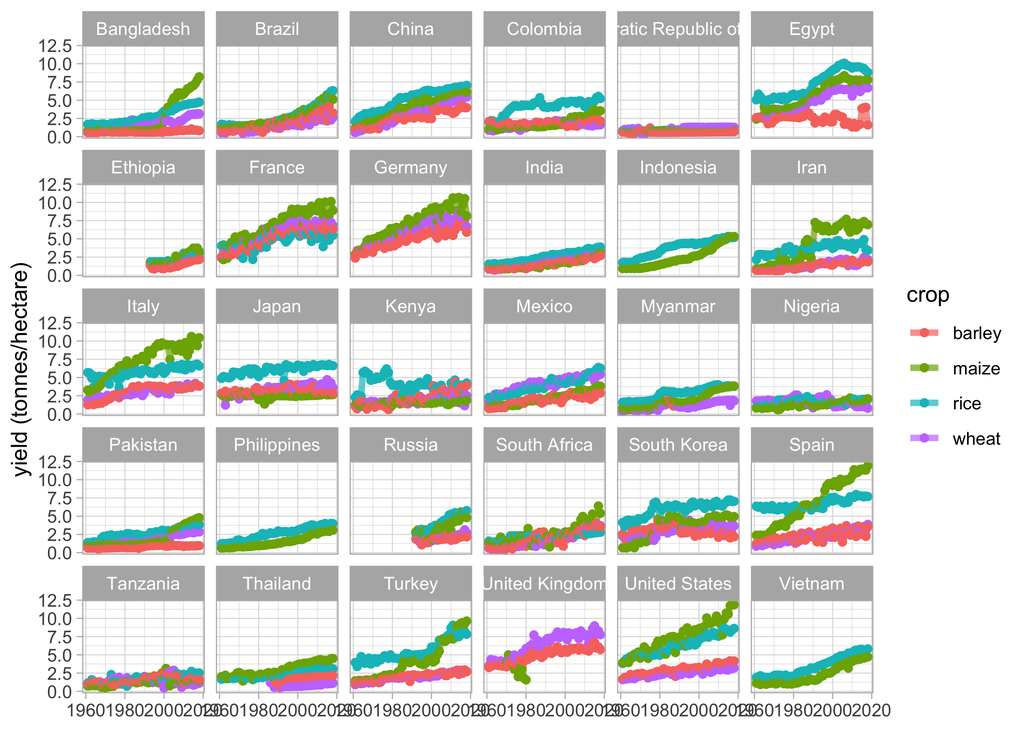

```r
tidy_yields %>%
  ggplot(aes(x = year, y = yield, color = crop)) +
  geom_line(alpha = 0.7, size = 1.5) +
  geom_point() +
  facet_wrap(~entity) +
  labs(x = NULL, y = "yield (tonnes/hectare)")
```

Notice that not all countires produce all crops for e.g. Indonesia, Vietnam and Philippines. But from this simple line plot, we can observe that overall crop yields are increasing.

## Create Models

```r
library(tidymodels)

tidy_lm <-
  tidy_yields %>%
  nest(yields = c(year, yield)) %>%
  mutate(model = map(yields, ~ lm(yield ~ year, data = .x)))

slopes <- tidy_lm %>%
  mutate(coefs = map(model, tidy)) %>%
  unnest(coefs) %>%
  filter(term == "year") %>%
  mutate(p.value = p.adjust(p.value))
```

## Explore Results

Let's visualize the output

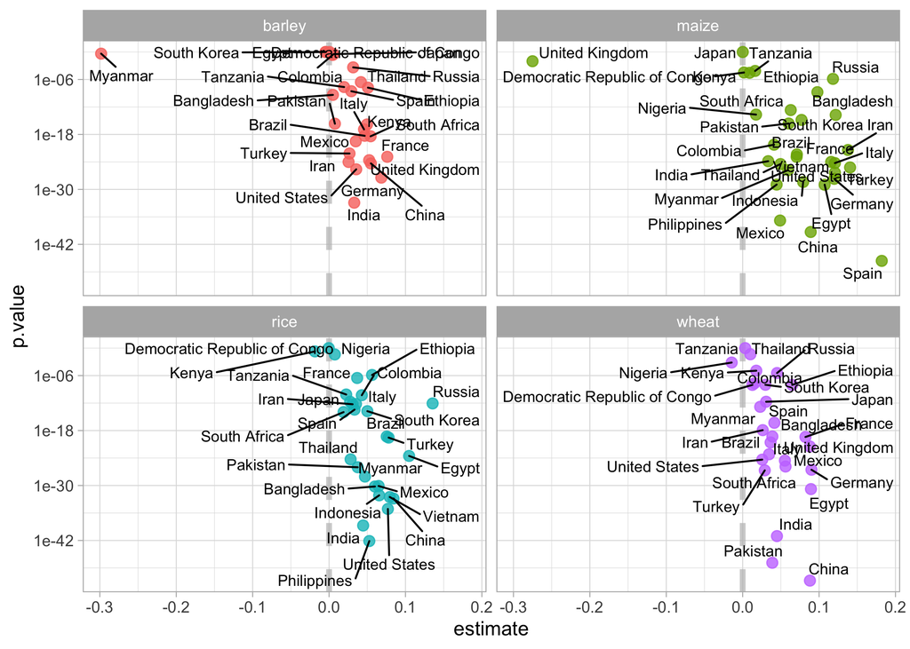

```r
library(ggrepel)
slopes %>%
  ggplot(aes(x = estimate, y = p.value, label = entity)) +
  geom_vline(xintercept = 0, lty = 2, size = 1.5, alpha = 0.7,
             color = 'gray') +
  geom_point(aes(color = crop), alpha = 0.8, size = 2.5,
             show.legend = FALSE) +
  geom_text_repel(size = 3) +
  facet_wrap(~ crop) +
  scale_y_log10()
```

- x-axis: gives us the slope of these models. Preliminary observation tells us that most countries have positive slope with increasing crop yields. Furthermore, the further to the right a country is, the larger the increase in crop yield over this time period. Lastly, corn yields have increased the most. - y-axis: gives the adjusted p-values, which measure how suprising the effect we see is under the assumption of no relationship (i.e. no change with time). Countries lower the plots have smaller adjusted p-values which have more certainty whether the relationships are real.